# Week 3: Logistic regression

### *Description of the exercise phases and interpretation of the results*

## Part 1: Data

### Data description

Data for this week’s exercise is retrieved from UCI Machine Learning Repository by Paulo Cortez in 2008 (University of Minho, Portugal). Data consists of two joined dataframes about students’ achievements in secondary education in two Portuguese schools. The first table was with students taking the math course, and the other taking the Portuguese course. For this exercise, the two datasets have been joined together (code for the data wrangling operations is [here](https://github.com/saratodorovic/IODS-project/blob/master/data/create_alc.R)).

Glimpse of the data:

| school | sex | age | address | famsize | Pstatus | Medu | Fedu | Mjob | Fjob | reason | nursery | internet | guardian | traveltime | studytime | failures | schoolsup | famsup | paid | activities | higher | romantic | famrel | freetime | goout | Dalc | Walc | health | absences | … |
| --- | --- | --- | --- | --- | --- | --- | --- | --- | --- | --- | --- | --- | --- | --- | --- | --- | --- | --- | --- | --- | --- | --- | --- | --- | --- | --- | --- | --- | --- | --- |
| GP | F | 18 | U | GT3 | A | 4 | 4 | at_home | teacher | course | yes | no | mother | 2 | 2 | 0 | yes | no | no | no | yes | no | 4 | 3 | 4 | 1 | 1 | 3 | 5 | … |
| GP | F | 17 | U | GT3 | T | 1 | 1 | at_home | other | course | no | yes | father | 1 | 2 | 0 | no | yes | no | no | yes | no | 5 | 3 | 3 | 1 | 1 | 3 | 3 | … |
| GP | F | 15 | U | LE3 | T | 1 | 1 | at_home | other | other | yes | yes | mother | 1 | 2 | 2 | yes | no | yes | no | yes | no | 4 | 3 | 2 | 2 | 3 | 3 | 8 | … |
| GP | F | 15 | U | GT3 | T | 4 | 2 | health | services | home | yes | yes | mother | 1 | 3 | 0 | no | yes | yes | yes | yes | yes | 3 | 2 | 2 | 1 | 1 | 5 | 1 | … |

**Column names for the dataset are:**

```r
colnames(alc)
```

```
##  [1] "school"     "sex"        "age"        "address"    "famsize"
##  [6] "Pstatus"    "Medu"       "Fedu"       "Mjob"       "Fjob"
## [11] "reason"     "nursery"    "internet"   "guardian"   "traveltime"
## [16] "studytime"  "failures"   "schoolsup"  "famsup"     "paid"
## [21] "activities" "higher"     "romantic"   "famrel"     "freetime"
## [26] "goout"      "Dalc"       "Walc"       "health"     "absences"
## [31] "G1"         "G2"         "G3"         "alc_use"    "high_use"
```

**Structure of the data is the following:**  
Observations: 382  
Variables: 35

```r
summary(alc)
```

```
##  school   sex          age        address famsize   Pstatus
##  GP:342   F:198   Min.   :15.00   R: 81   GT3:278   A: 38
##  MS: 40   M:184   1st Qu.:16.00   U:301   LE3:104   T:344
##                   Median :17.00
##                   Mean   :16.59
##                   3rd Qu.:17.00
##                   Max.   :22.00
##       Medu            Fedu             Mjob           Fjob
##  Min.   :0.000   Min.   :0.000   at_home : 53   at_home : 16
##  1st Qu.:2.000   1st Qu.:2.000   health  : 33   health  : 17
##  Median :3.000   Median :3.000   other   :138   other   :211
##  Mean   :2.806   Mean   :2.565   services: 96   services:107
##  3rd Qu.:4.000   3rd Qu.:4.000   teacher : 62   teacher : 31
##  Max.   :4.000   Max.   :4.000
##         reason    nursery   internet    guardian     traveltime
##  course    :140   no : 72   no : 58   father: 91   Min.   :1.000
##  home      :110   yes:310   yes:324   mother:275   1st Qu.:1.000
##  other     : 34                       other : 16   Median :1.000
##  reputation: 98                                    Mean   :1.448
##                                                    3rd Qu.:2.000
##                                                    Max.   :4.000
##    studytime        failures      schoolsup famsup     paid     activities
##  Min.   :1.000   Min.   :0.0000   no :331   no :144   no :205   no :181
##  1st Qu.:1.000   1st Qu.:0.0000   yes: 51   yes:238   yes:177   yes:201
##  Median :2.000   Median :0.0000
##  Mean   :2.037   Mean   :0.2016
##  3rd Qu.:2.000   3rd Qu.:0.0000
##  Max.   :4.000   Max.   :3.0000
##  higher    romantic      famrel         freetime        goout
##  no : 18   no :261   Min.   :1.000   Min.   :1.00   Min.   :1.000
##  yes:364   yes:121   1st Qu.:4.000   1st Qu.:3.00   1st Qu.:2.000
##                      Median :4.000   Median :3.00   Median :3.000
##                      Mean   :3.937   Mean   :3.22   Mean   :3.113
##                      3rd Qu.:5.000   3rd Qu.:4.00   3rd Qu.:4.000
##                      Max.   :5.000   Max.   :5.00   Max.   :5.000
##       Dalc            Walc           health         absences
##  Min.   :1.000   Min.   :1.000   Min.   :1.000   Min.   : 0.0
##  1st Qu.:1.000   1st Qu.:1.000   1st Qu.:3.000   1st Qu.: 1.0
##  Median :1.000   Median :2.000   Median :4.000   Median : 3.0
##  Mean   :1.482   Mean   :2.296   Mean   :3.573   Mean   : 4.5
##  3rd Qu.:2.000   3rd Qu.:3.000   3rd Qu.:5.000   3rd Qu.: 6.0
##  Max.   :5.000   Max.   :5.000   Max.   :5.000   Max.   :45.0
##        G1              G2              G3           alc_use
##  Min.   : 2.00   Min.   : 4.00   Min.   : 0.00   Min.   :1.000
##  1st Qu.:10.00   1st Qu.:10.00   1st Qu.:10.00   1st Qu.:1.000
##  Median :12.00   Median :12.00   Median :12.00   Median :1.500
##  Mean   :11.49   Mean   :11.47   Mean   :11.46   Mean   :1.889
##  3rd Qu.:14.00   3rd Qu.:14.00   3rd Qu.:14.00   3rd Qu.:2.500
##  Max.   :18.00   Max.   :18.00   Max.   :18.00   Max.   :5.000
##   high_use
##  Mode :logical
##  FALSE:268
##  TRUE :114
##  NA's :0
##
##
```

**Information about the attributes:**  
- school - student’s school (binary: ‘GP’ - Gabriel Pereira or ‘MS’ - Mousinho da Silveira)  
- sex - student’s sex (binary: ‘F’ - female or ‘M’ - male)  
- age - student’s age (numeric: from 15 to 22)  
- address - student’s home address type (binary: ‘U’ - urban or ‘R’ - rural)  
- famsize - family size (binary: ‘LE3’ - less or equal to 3 or ‘GT3’ - greater than 3)  
- Pstatus - parent’s cohabitation status (binary: ‘T’ - living together or ‘A’ - apart)  
- Medu - mother’s education (numeric: 0 - none, 1 - primary education (4th grade), 2 - 5th to 9th grade, 3 - secondary education or 4 - higher education)  
- Fedu - father’s education (numeric: 0 - none, 1 - primary education (4th grade), 2 - 5th to 9th grade, 3 - secondary education or 4 - higher education)  
- Mjob - mother’s job (nominal: ‘teacher’, ‘health’ care related, civil ‘services’ (e.g. administrative or police), ‘at_home’ or ‘other’)  
- Fjob - father’s job (nominal: ‘teacher’, ‘health’ care related, civil ‘services’ (e.g. administrative or police), ‘at_home’ or ‘other’)  
- reason - reason to choose this school (nominal: close to ‘home’, school ‘reputation’, ‘course’ preference or ‘other’)  
- guardian - student’s guardian (nominal: ‘mother’, ‘father’ or ‘other’)  
- traveltime - home to school travel time (numeric: 1 - <15 min., 2 - 15 to 30 min., 3 - 30 min. to 1 hour, or 4 - >1 hour)  
- studytime - weekly study time (numeric: 1 - <2 hours, 2 - 2 to 5 hours, 3 - 5 to 10 hours, or 4 - >10 hours)  
- failures - number of past class failures (numeric: n if 1<=n<3, else 4)  
- schoolsup - extra educational support (binary: yes or no)  
- famsup - family educational support (binary: yes or no)  
- paid - extra paid classes within the course subject (Math or Portuguese) (binary: yes or no)  
- activities - extra-curricular activities (binary: yes or no)  
nursery - attended nursery school (binary: yes or no)  
- higher - wants to take higher education (binary: yes or no)  
- internet - Internet access at home (binary: yes or no)  
- romantic - with a romantic relationship (binary: yes or no)  
- famrel - quality of family relationships (numeric: from 1 - very bad to 5 - excellent)  
- freetime - free time after school (numeric: from 1 - very low to 5 - very high)  
- goout - going out with friends (numeric: from 1 - very low to 5 - very high)  
- Dalc - workday alcohol consumption (numeric: from 1 - very low to 5 - very high)  
- Walc - weekend alcohol consumption (numeric: from 1 - very low to 5 - very high)  
- health - current health status (numeric: from 1 - very bad to 5 - very good)  
- absences - number of school absences (numeric: from 0 to 93)

*these grades are related with the course subject, Math or Portuguese:*  
- G1 - first period grade (numeric: from 0 to 20)  
- G2 - second period grade (numeric: from 0 to 20)  
- G3 - final grade (numeric: from 0 to 20, output target)

*these varables were created for the dataframe combining the alcohol consumption*  
- alc_use - Average alcochol use on weekdays and weekends together  
- high_use - High alcohol use (alc_use > 2), logical (T/F)

## Part 2: Data Analysis

Purpose of this analysis is to study the relationships between high and low alcohol consumption and four other chosen variables, and to numerically and graphically show the distributions between the variables.  
Logistic regression is used to define the linear model for binary value “success”, the expected value of the target variable.

##### **1. Choosing the four variables**

The dataset is quite interesting, because it provides multiple socially interesting factors to compare with each other. The four variables I chose to compare with the alcohol comsumption are *health, G3 (total grades), studytime and absences*. Generally research concludes that [men exceed women in high-volume drinking](https://www.ncbi.nlm.nih.gov/pmc/articles/PMC2844334/), but research also says that [there is a clear female excess for the risk of becoming an underaged drinker](https://onlinelibrary.wiley.com/doi/full/10.1111/acer.13028). That’s why I’m including the gender variable in my analysis as well.

##### **2. My personal hypotheses for each variables**

**health**: Alcohol affects the human health, so logically high consumption would affect the health status, and that students who consume less alcohol would be healthier. So I believe there might be a connection, but of course other factors, like eating habits and sports affect more. **G3 (grades)**: I believe there might be some connection, that students who consume more alcohol tend to get lower grades, but that the distribution is not that big.  
**studytime** : I believe there can be seen some kind of correlation between alcohol consumption and studytime. **absences**: I believe high alcohol consumption leads to more school absences.

##### **3. Distributions of variables to alcohol consumption**

**Comparison of predictive variables with the target variable (high_use):**

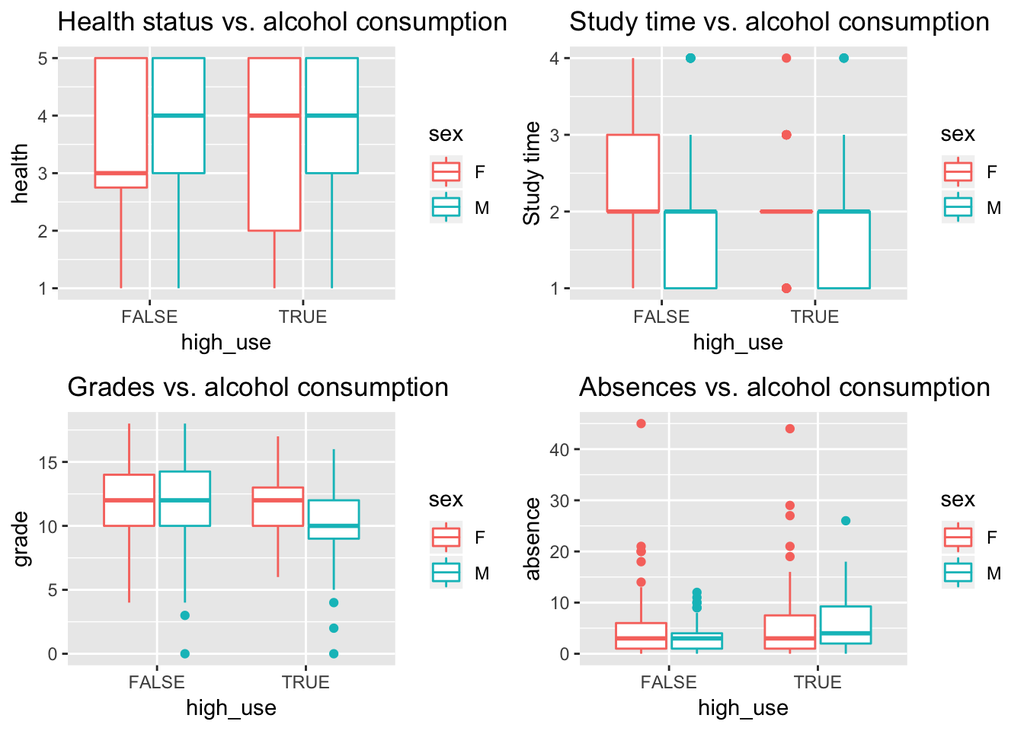

```r
# First plot: Distributions of high alcohol consumption and health status with gender distinction
g1 <- ggplot(alc, aes(x = high_use, y = health, col=sex)) + geom_boxplot() + ggtitle("Health status vs. alcohol consumption")

# Second plot: Distributions of high alcohol consumption and G3(grades) with gender distinction
g2 <- ggplot(alc, aes(x = high_use, y = G3, col = sex)) + geom_boxplot() + ylab("grade") + ggtitle("Grades vs. alcohol consumption")

# Third plot: Distributions of high alcohol consumption and study time with gender distinction
g3 <- ggplot(alc, aes(x = high_use, y = studytime, col = sex)) + geom_boxplot() + ylab("Study time") + ggtitle("Study time vs. alcohol consumption")

# Fourth plot: Distributions of high alcohol consumption and school absences with gender distinction
g4 <- ggplot(alc, aes(x = high_use, y = absences, col = sex)) + geom_boxplot() + ylab("absence") + ggtitle("Absences vs. alcohol consumption")

plot <- multiplot(g1, g2, g3, g4, cols=2) + geom_smooth(method = 'loess')
```

**Summary statistics:**

```r
alc %>% group_by(sex, high_use) %>% summarise(count = n(), mean_health = mean(health), mean_studytime = mean(studytime), mean_grade = mean(G3), mean_absence = mean(absences))
```

```
## # A tibble: 4 x 7
## # Groups:   sex [?]
##   sex   high_use count mean_health mean_studytime mean_grade mean_absence
##   <fct> <lgl>    <int>       <dbl>          <dbl>      <dbl>        <dbl>
## 1 F     FALSE      156        3.38           2.34       11.4         4.22
## 2 F     TRUE        42        3.40           2          11.7         6.79
## 3 M     FALSE      112        3.71           1.88       12.2         2.98
## 4 M     TRUE        72        3.88           1.64       10.3         6.12
```

### Interpretation

As the data was grouped by gender, we can see results for both male and female high and low alcohol consumers.

- In plot 1 in upper left, health status is generally the same for both male and female students, with a drop in the median value within low-alcohol consuming female students, which is slightly surprising. Male students have exactly same range of answers and the same median value of 4, when female high-alcohol consuming students’s answers are more dispersed. In the summary table we can see that the mean health statuses are quite the same for both genders, but high-alcohol consuming students have estimated their health status to be slightly better than low-alcohol consumers.
- In plot 2 on the upper right the study times differ between genders more than between the consumption factor. Therefore my hypothesis that there is a correlation between alcohol consumption and study time does not quite make sense, but it can be seen from the statistics that boys study less but also both boys and girls who consume more alcohol study a bit less in average.
- In plot 3 in down left, we can see that the grades are quite equally distributed with students who are low-alcohol consumers. Withing students who are high-alcohol students, girls get generally slightly better grades than boys, and only boys have clear outliers from the data (with bad grades) in both low- and high-alcohol consuming students. So according to my hypothesis, alcohol consumption has an effect on total grades, but might still not be the only explanatory factor.
- In plot 4 in down right, can be seen that girls in both groups have more outlier individuals with many absences. As box the statistics, we can see that high-alcohol consuming students have averagely more absences in both gender classes.

## Part 3: Logistic regression

### Logistic regression to find relationships between variables

First we will create a logistic regression model and study its summary and coefficients.

```r
m <- glm(high_use ~ sex + health + studytime + G3 + absences , data = alc, family = "binomial")
summary(m)
```

```
##
## Call:
## glm(formula = high_use ~ sex + health + studytime + G3 + absences,
##     family = "binomial", data = alc)
##
## Deviance Residuals:
##     Min       1Q   Median       3Q      Max
## -2.1871  -0.8325  -0.6075   1.0677   2.2106
##
## Coefficients:
##             Estimate Std. Error z value Pr(>|z|)
## (Intercept) -0.42587    0.64922  -0.656 0.511845
## sexM         0.81236    0.25409   3.197 0.001388 **
## health       0.03196    0.08731   0.366 0.714366
## studytime   -0.35579    0.16124  -2.207 0.027344 *
## G3          -0.06155    0.03665  -1.679 0.093089 .
## absences     0.08642    0.02299   3.759 0.000171 ***
## ---
## Signif. codes:  0 '***' 0.001 '**' 0.01 '*' 0.05 '.' 0.1 ' ' 1
##
## (Dispersion parameter for binomial family taken to be 1)
##
##     Null deviance: 465.68  on 381  degrees of freedom
## Residual deviance: 420.17  on 376  degrees of freedom
## AIC: 432.17
##
## Number of Fisher Scoring iterations: 4
```

```r
coef(m)
```

```
## (Intercept)        sexM      health   studytime          G3    absences
## -0.42586809  0.81236413  0.03195670 -0.35578595 -0.06155365  0.08642112
```

**Next let’s see the coefficients as odd ratios:**

```r
m <- glm(high_use ~ sex + studytime + absences , data = alc, family = "binomial")
# compute odds ratios (OR)
OR <- coef(m) %>% exp
# Computing confidence intervals (CI)
CI <- confint(m) %>% exp
# Printing out the odds ratios with their confidence intervals
cbind(OR, CI)
```

```
##                    OR     2.5 %    97.5 %
## (Intercept) 0.3993889 0.1760458 0.8977721
## sexM        2.2216751 1.3647760 3.6532630
## studytime   0.6686620 0.4847669 0.9067963
## absences    1.0928234 1.0467369 1.1459745
```

- The larger the Odd Ratio, the more positive relationship. We see that sex and absences have the highest Odd Ratios, and that sex has also the biggest confidence interval.

## Part 4: Predictions

In this part the predictive power of the model will be explored.

```r
# Fitting the model with statistically significant variables
m <- glm(high_use ~ sex + absences + studytime, data = alc, family = "binomial")

# Predict() the probability of high_use
probabilities <- predict(m, type = "response")

# Add the predicted probabilities to 'alc'
alc <- mutate(alc, probability = probabilities)

# Use the probabilities to make a prediction of high_use
alc <- mutate(alc, prediction = probabilities > 0.5)

# Tabulate the target variable versus the predictions
table(high_use = alc$high_use, prediction = alc$prediction)%>% prop.table %>% addmargins()
```

```
##         prediction
## high_use      FALSE       TRUE        Sum
##    FALSE 0.67539267 0.02617801 0.70157068
##    TRUE  0.23036649 0.06806283 0.29842932
##    Sum   0.90575916 0.09424084 1.00000000
```

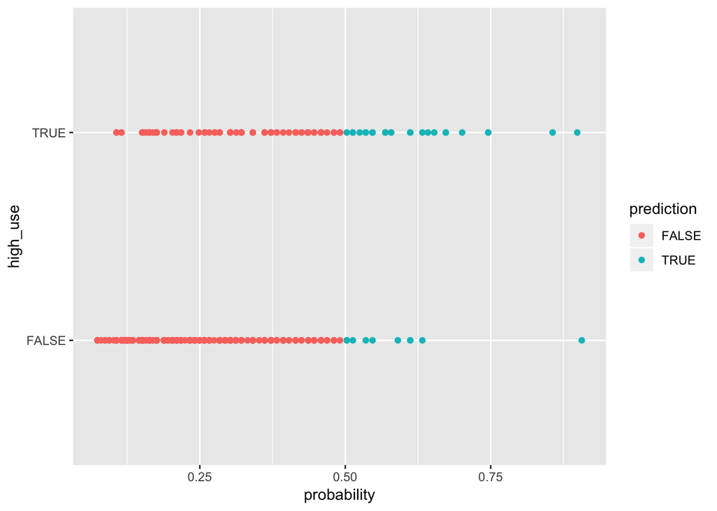

```r
ggplot(alc, aes(x = probability, y = high_use, col=prediction)) + geom_point()
```

- From the plot and the data we see that the model predicts less students do belong to high-alcohol consumption category.
- Model’s are never perfect, since there is always a chance of incorrectly classified observations. The the model’s average number of wrong predictions can be computed with accuracy and loss function. The smaller the number (in scale from 0-1), the better, since it means less errors.

```r
# Defining a loss function (mean prediction error)
loss_func <- function(class, prob) {
  n_wrong <- abs(class - prob) > 0.5
  mean(n_wrong)
}

# Calling loss_func to compute the average number of wrong predictions in the (training) data
loss_func(class = alc$high_use, alc$probability)
```

```
## [1] 0.2565445
```

- 0.2565 is the number of errors retreived using loss function

**EXTRA:**  
When conducting a 10-fold cross-validation to the model, we get following results:

```r
library(boot)
# K-fold cross validation, K = 10 because of the 10-fold CV
cv <- cv.glm(data = alc, cost = loss_func, glmfit = m, K = 10)

# average number of wrong predictions in the cross validation
cv$delta[1]
```

```
## [1] 0.2591623
```